# Urban Land-Use Efficiency

Supplementary Material · Sub-national Case Study: Germany (Kreis Level), Why Per-Capita Designs Cannot Cleanly Identify Its Drivers : 400 German Districts x 2000-2020 Panel Data Analysis

Author

Affiliation

Ömer Furkan Çoban

Carl von Ossietzky University of Oldenburg

Published

June 26, 2026

Abstract

This supplement replicates the paper’s driver analysis for the Built-up per Capita Rate (BpCR) at the sub-national level, using Germany (district / *Kreis* level) as a case study, and brings in internal (within-country) migration, which the national analysis cannot observe. It asks whether the within-country income, densification, and path-dependence results survive at a finer spatial scale.

Keywords

SDG 11.3.1, Built-up per capita rate (BpCR), Sub-national analysis, Germany / Kreise, Internal migration

# 1 Data and Method

The dependent variable is built exactly as in the main paper, but for German districts (*Kreise*) rather than countries. Urban built-up area $V$ and urban population $P$ come from the GHSL grids (Pesaresi et al. 2024; Schiavina et al. 2023) (urban-masked at GHS-SMOD $\geq 21$), aggregated to the GAUL level-2 units for Germany at the five-year epochs 1985–2020; BpCR and urban density are then computed from these totals just as nationally. Three series are taken from the German regional database INKAR (BBSR 2024), published by the Federal Institute for Research on Building, Urban Affairs and Spatial Development (BBSR) and accessed through the author’s `inkaR` R package (Çoban 2026): GDP per capita (workplace-based), the **internal net-migration rate** (*Binnenwanderungssaldo*, reported per 1,000 inhabitants and rescaled here to a percentage of population for comparability with the national control), the latter being the within-country flow that the national UN measure omits, and total district population, which serves as the denominator of the urban population share (GHSL urban population over INKAR total district population). GAUL districts are matched to INKAR *Kreise* on a cleaned base name, disambiguating same-named *kreisfreie Stadt* / *Landkreis* twins by geographic area, so that 399 of Germany’s 400 districts enter the regressions. The single exception is Freyung-Grafenau, a rural Bavarian-Forest district whose largest settlement reaches only the rural-cluster class (GHS-SMOD 13): no cell attains the urban threshold (SMOD $\geq 21$), so its urban built-up area and population are zero and BpCR is undefined. This is the same urban definition used throughout the paper, under which a unit with no urban cells is simply not an urban observation, not a matching failure. The panel spans the epochs 1995–2020 for which the INKAR controls are available (2394 district-periods). All specifications carry district and period fixed effects with standard errors clustered by district; the dynamic models add the lagged dependent variable and use Arellano-Bond and Blundell-Bond GMM, as in the main paper.

Figure 1 shows the same SDG 11.3.1 construction at the German district scale, for Berlin and the surrounding Brandenburg countryside. As in the national figure, built-up surface (panel b) is retained only where the GHS-SMOD grid classifies a cell as urban (SMOD at least 21, panel c), giving the urban-masked built-up that enters the analysis as $V$ (panel d); urban population $P$ is masked the same way. The cyan line is the Berlin state boundary: the dense urban core falls inside it, while the rural matrix that the mask removes makes up most of the surrounding districts.

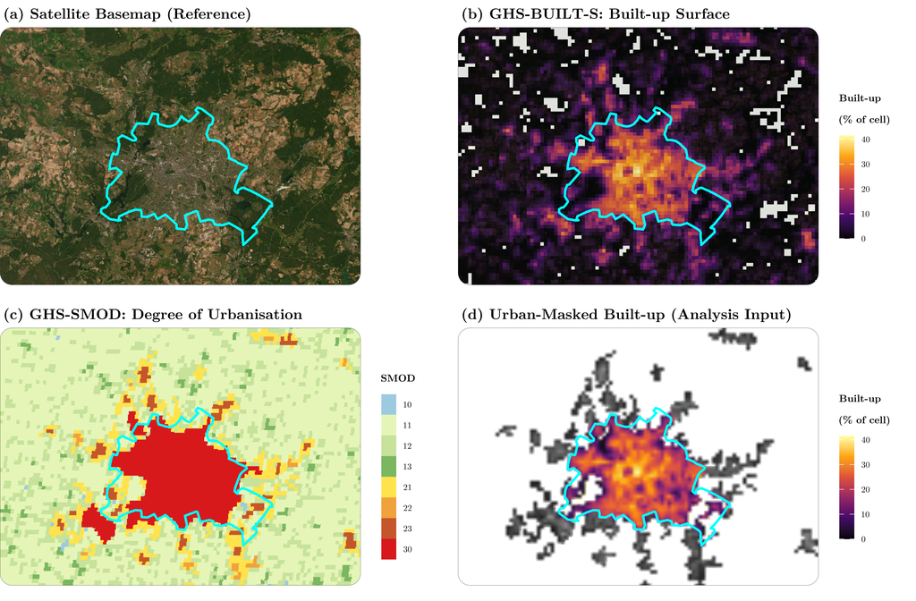

Figure 1: Building the analysis input following the SDG 11.3.1 metadata at the German *Kreis* scale (Berlin / Brandenburg window), each layer drawn over an Esri satellite basemap. (a) Basemap with the Berlin state boundary (cyan). (b) GHS-BUILT-S built-up surface, shown as the built-up share of each 1 km cell. (c) GHS-SMOD Degree of Urbanisation (1 km); cells coded 21 or higher count as urban. (d) Urban-masked built-up, the input actually used: panel (b) kept only where panel (c) is urban.

# 2 Drivers of Per-Capita Land Use

We estimate the drivers of BpCR at the district level exactly as in the main paper: a two-way fixed-effects model built up control-by-control, then Arellano-Bond (Arellano and Bond 1991) (difference) and Blundell-Bond (Blundell and Bond 1998) (system) GMM that add the lagged dependent variable to capture path-dependence and correct its Nickell bias. The key addition relative to the national models is **internal (within-country) net migration**, the INKAR *Binnenwanderungssaldo*, which the national panel (international migration only) cannot observe.

Table 1: Dynamic-panel model at the German Kreis level: FE stepwise build-up, Arellano-Bond (difference) and Blundell-Bond (system) GMM.

| Variables | Dependent variable: BpCR Fixed Effects Base | Dependent variable: BpCR Fixed Effects + Density | Dependent variable: BpCR Fixed Effects + Net Migr. | Dependent variable: BpCR Fixed Effects + GDP | Dependent variable: BpCR Fixed Effects + Urban % | Dependent variable: BpCR GMM (Bias-Corrected) Arellano-Bond | Dependent variable: BpCR GMM (Bias-Corrected) Blundell-Bond |
| --- | --- | --- | --- | --- | --- | --- | --- |
| BpCR[t−1] | +0.3461*** | +0.4026*** | +0.4023*** | +0.4124*** | +0.3939*** | +0.1687*** | +0.1479* |
|  | (0.0469) | (0.0362) | (0.0360) | (0.0343) | (0.0347) | (0.0432) | (0.0812) |
| ln(Urban Density)[t−1] |  | +0.0441*** | +0.0440*** | +0.0467*** | +0.0452*** | +0.0562*** | -0.0049*** |
|  |  | (0.0041) | (0.0041) | (0.0038) | (0.0034) | (0.0043) | (0.0011) |
| Internal Net Migration (% Pop) |  |  | -0.0000 | -0.0000 | -0.0001 | -0.0001 | -0.0006 |
|  |  |  | (0.0001) | (0.0001) | (0.0001) | (0.0001) | (0.0005) |
| ln(GDP per capita) |  |  |  | +0.0079*** | +0.0086*** | +0.0017 | -0.0037*** |
|  |  |  |  | (0.0017) | (0.0017) | (0.0017) | (0.0007) |
| Urban Pop. Share[t−1] |  |  |  |  | +0.0274*** | +0.0134** | -0.0049*** |
|  |  |  |  |  | (0.0050) | (0.0068) | (0.0015) |
| Observations | 1,995 | 1,995 | 1,995 | 1,995 | 1,995 | 1,596 | 1,995 |
| Within R$^2$ | 0.094 | 0.253 | 0.253 | 0.266 | 0.284 | – | – |
| District FE | Yes | Yes | Yes | Yes | Yes | Yes | Yes |
| Period FE | Yes | Yes | Yes | Yes | Yes | Yes | Yes |
| Instruments | – | – | – | – | – | 10 | 16 |
| Hansen (p) | – | – | – | – | – | 0.00 | 0.00 |
| AR(1) (p) | – | – | – | – | – | 0.01 | 0.07 |
| AR(2) (p) | – | – | – | – | – | 0.00 | 0.03 |

*Note:* *** p<0.01, ** p<0.05, * p<0.1. Standard errors in parentheses: clustered by district in the fixed-effects columns; two-step GMM with the Windmeijer finite-sample correction (Windmeijer 2005) in the Arellano-Bond and Blundell-Bond columns. The lagged dependent variable is instrumented by lags 2 to 3 of BpCR, with the instrument matrix collapsed. In the GMM columns the Observations row reports post-transformation equation observations (the differenced-equation set for Arellano-Bond; the larger level-equation set for Blundell-Bond). Sample: 399 of Germany’s 400 districts; Freyung-Grafenau is excluded because no cell reaches the urban threshold (SMOD of at least 21), leaving its urban built-up and population at zero and BpCR undefined.

Three points emerge. First, per-capita land use is **path-dependent** at the district level too: the lagged dependent variable is positive and significant in every fixed-effects specification ($\rho \approx 0.39$ in the full model), echoing the persistence found across countries, so that result is not an artefact of country-level aggregation; we read persistence from these columns rather than from the dynamic-GMM point estimate, whose own specification tests fail below, the same standard the main paper applies to its own Hansen-failing full-model estimate. Second, the **income** coefficient is *positive* and significant under fixed effects (+0.0079 in the +GDP column), the opposite sign from the persistently negative, though insignificant, national estimate; it turns insignificant in Arellano-Bond and negative and significant in Blundell-Bond, so no stable income effect emerges from this shorter panel either, but it is not the same null found nationally. Third, **internal net migration**, the flow the national panel cannot observe, enters with an essentially zero coefficient: six five-year epochs give little power to identify a within-district migration channel, and unlike the national international-migration result it is not robust across specifications.

*The GMM does not survive the correct timing.* With the controls dated $t-1$, the district Arellano-Bond estimator fails both of its specification tests (Hansen and AR(2) reject), where the same estimator with contemporaneous controls passes them. We report the columns for completeness but draw no conclusion from them: at this scale, with the controls correctly timed, the differenced equation retains too few epochs for the deep-lag moment conditions to hold. The fixed-effects columns, which need no instrument validity, carry the district evidence.

# 3 Timing and the Compact-City Artefact

The main paper’s central methodological claim is that urban density and urban population share are arithmetically entangled with BpCR, which contains urban population negatively at $t$ and positively at $t-1$, so each control inherits the sign of the date at which it is measured. The German districts provide an independent test of that claim on different data, at a different scale, with a different migration control. Table 2 re-estimates the fixed-effects model under the three timings on one common sample.

Table 2: Timing of the two population-sharing controls at the German Kreis level: two-way fixed effects on the common sample where t, t-1 and t-2 are all observed. Only the t-2 column shares no term with the dependent variable.

| Term | Dependent variable: BpCR (fixed effects) Timing of density / urban share Both t | Dependent variable: BpCR (fixed effects) Timing of density / urban share Both t-1 | Dependent variable: BpCR (fixed effects) Timing of density / urban share Both t-2 (clean) |
| --- | --- | --- | --- |
| BpCR[t−1] | +0.2021*** | +0.2261*** | +0.0569 |
|  | (0.0707) | (0.0378) | (0.0446) |
| ln(Urban Density) | -0.0294*** | +0.0438*** | +0.0310*** |
|  | (0.0067) | (0.0046) | (0.0041) |
| Internal Net Migration (% Pop) | -0.0004** | +0.0003 | +0.0002 |
|  | (0.0002) | (0.0002) | (0.0002) |
| ln(GDP per capita) | -0.0014 | +0.0080*** | +0.0076*** |
|  | (0.0021) | (0.0021) | (0.0020) |
| Urban Pop. Share | -0.0442*** | +0.0233*** | +0.0428*** |
|  | (0.0130) | (0.0072) | (0.0066) |
| Observations | 1,596 | 1,596 | 1,596 |

Urban density reproduces the national pattern closely. It is **$-0.029$** ($p<0.01$) when measured contemporaneously, **$+0.044$** at $t-1$, and **$+0.031$** ($p<0.01$) at the mechanically clean $t-2$ timing, the same sign sequence as the national $-0.024$, $+0.009$, and $+0.011$ ($p<0.05$). Urban share shows the same sign flip at $t$ and $t-1$ ($-0.044$, then $+0.023$) but diverges at the clean timing: **$+0.043$** ($p<0.01$) here against an insignificant $-0.012$ nationally, so unlike density its clean-timing reading does not replicate. The persistence term itself loses significance here ($+0.057$, against a stable $0.20$–$0.25$ nationally), likely the extra sample loss from a second lag; we do not read $\rho$ from this column. The district-level accounting check gives the same signature as the national one: regressing BpCR on urban population at $t$ and $t-1$ within districts returns $-0.011$ and $+0.013$, equal and opposite. Since these are different data, a different country, a different spatial scale, and a different migration control, the density reproduction is strong evidence that the compact-city sign in per-capita land-use regressions is arithmetic rather than economic, exactly as the main paper argues. **H2 finds no support here either.**

# 4 Limitations

Several limitations qualify this case study and mark it as a corroborating local illustration rather than a stand-alone causal analysis.

*Coverage and matching.* GAUL districts are matched to INKAR by name (399 of Germany’s 400 districts); the only exclusion, Freyung-Grafenau, has no urban-classified cells and hence no defined BpCR. The match relies on a cleaned base name with an area-based rule for same-named city/rural twins rather than an official code, so it is accurate here but would need a code crosswalk to be fully automatic in other settings.

*Short, recent panel.* The INKAR controls are available only from 1995, so BpCR is estimable over six five-year epochs (1995–2020), shorter than the national panel. A further epoch is lost to lagging: 1995’s urban population share is observed, but its 1990 lag is not, since the INKAR series itself starts only in 1995, so every column in Table 1 runs on 2000–2020 (five epochs, 1995 district-periods, not the full 2,394), and the models speak to medium-run trajectories rather than short-run adjustment. Differencing costs Arellano-Bond one epoch more, retaining 2005–2020 only.

*GMM diagnostics.* Once the population-sharing controls are correctly dated at $t-1$, neither dynamic estimator survives its specification tests at this scale: the Arellano-Bond Hansen and AR(2) tests both reject, as do Blundell-Bond’s. Arellano-Bond passes both with contemporaneous controls, an artefact per Section 3 and so no comfort; Blundell-Bond fails regardless of timing, a feature of the system estimator here, not a timing artefact. The reason is mechanical: lagging the controls costs the district panel an epoch, leaving the differenced equation too few periods for deep-lag moments to hold. We therefore draw the district conclusions from the fixed-effects columns, which require no instrument validity, and report the GMM columns only for completeness. This is a limitation of the district panel’s length, not a challenge to the national GMM, which is estimated on eight epochs and passes its AR(2) test comfortably.

*Internal migration.* The internal net-migration control (INKAR *Binnenwanderungssaldo*) is the within-country flow the national analysis cannot observe, and it was the main reason for building this case study. It does not deliver: within districts its coefficient is essentially zero, and it is not robust to the timing of the other controls (Table 2). This is a substantive disappointment rather than a technicality, since the national paper’s strongest result is the *international* migration channel and the natural conjecture is that internal flows work the same way. A plausible reading is that any clearer migration-densification association is cross-sectional (denser districts attract internal migrants), a pattern this within-district design does not test formally; four to six epochs in any case give little power. Identifying the internal channel convincingly would need a longer or finer panel, and remains the most valuable extension of the national analysis.

*Measurement and scope.* As in the main paper, the built-up and population layers are satellite-based estimates, the urban area is defined at a fixed Degree-of-Urbanisation threshold (GHS-SMOD of at least 21), and present-day GAUL boundaries are applied throughout; the income and migration controls are administrative aggregates. The estimates are associations, not causal effects, and they describe a single country, so they illustrate rather than establish external validity.

# 5 Conclusion

The replication is the paper’s central methodological finding, and it is the most valuable thing here. Urban density is significantly *negative* when measured at the same date as the dependent variable and significantly *positive* at every timing that is not, including the arithmetically clean $t-2$ specification; the district accounting check reproduces the national one almost exactly (Section 3). Different data, different country, different scale, different migration measure, same signature. That the compact-city coefficient in per-capita land-use regressions is an artefact of the metric’s own arithmetic is therefore not a quirk of the global panel.

# References

Arellano, Manuel, and Stephen Bond. 1991. “Some Tests of Specification for Panel Data: Monte Carlo Evidence and an Application to Employment Equations.” *The Review of Economic Studies* 58 (2): 277–97. https://doi.org/10.2307/2297968.

BBSR. 2024. *INKAR: Indikatoren Und Karten Zur Raum- Und Stadtentwicklung*. Federal Institute for Research on Building, Urban Affairs and Spatial Development (BBSR), Bonn. https://www.inkar.de/.

Blundell, Richard, and Stephen Bond. 1998. “Initial Conditions and Moment Restrictions in Dynamic Panel Data Models.” *Journal of Econometrics* 87 (1): 115–43. https://doi.org/10.1016/S0304-4076(98)00009-8.

Çoban, Ömer Furkan. 2026. *inkaR: Download and Analyze Spatial Development Data from INKAR*. https://doi.org/10.32614/CRAN.package.inkaR.

Pesaresi, Martino, Marcello Schiavina, Panagiotis Politis, et al. 2024. “Advances on the Global Human Settlement Layer by Joint Assessment of Earth Observation and Population Survey Data.” *International Journal of Digital Earth* 17 (1). https://doi.org/10.1080/17538947.2024.2390454.

Schiavina, Marcello, Michele Melchiorri, and Martino Pesaresi. 2023. *GHS-SMOD R2023A - GHS Settlement Layers, Application of the Degree of Urbanisation Methodology (Stage i) to GHS-POP R2023A and GHS-BUILT-S R2023A, Multitemporal (1975-2030)*. European Commission, Joint Research Centre (JRC). https://doi.org/10.2905/A0DF7A6F-49DE-46EA-9BDE-563437A6E2BA.

Windmeijer, Frank. 2005. “A Finite Sample Correction for the Variance of Linear Efficient Two-Step GMM Estimators.” *Journal of Econometrics* 126 (1): 25–51. https://doi.org/10.1016/j.jeconom.2004.02.005.